# Regression Models - Course Project

dillonchewwx

17/02/2021

# Executive Summary

In this report, the `mtcars` dataset would be used to answer the following two questions:

1. Is an automatic or manual transmission better for MPG (miles per gallon)?
2. Quantify the MPG difference between automatic and manual transmissions.

Through a t-test, we have sufficient evidence (p=0.0014) to conclude that cars with manual transmissions provide better gas mileage than automatic transmission. Using regression models, a linear model shows that manual transmission provide 7.25 mpg more than automatic transmissions, but this single variable only accounts for 36% of the variation. By fitting additional variables to the model such as `disp`, `cyl`, `hp` and `wt`, the improvement was only 1.55 mpg, but this model accounts for 82.7% of the variation.

# Exploratory Data Analysis

We will begin by loading the `mtcars` dataset and examining it.

```r
library(datasets)
data(mtcars)
head(mtcars)
```

```
##                    mpg cyl disp  hp drat    wt  qsec vs am gear carb
## Mazda RX4         21.0   6  160 110 3.90 2.620 16.46  0  1    4    4
## Mazda RX4 Wag     21.0   6  160 110 3.90 2.875 17.02  0  1    4    4
## Datsun 710        22.8   4  108  93 3.85 2.320 18.61  1  1    4    1
## Hornet 4 Drive    21.4   6  258 110 3.08 3.215 19.44  1  0    3    1
## Hornet Sportabout 18.7   8  360 175 3.15 3.440 17.02  0  0    3    2
## Valiant           18.1   6  225 105 2.76 3.460 20.22  1  0    3    1
```

```r
str(mtcars)
```

```
## 'data.frame':    32 obs. of  11 variables:
##  $ mpg : num  21 21 22.8 21.4 18.7 18.1 14.3 24.4 22.8 19.2 ...
##  $ cyl : num  6 6 4 6 8 6 8 4 4 6 ...
##  $ disp: num  160 160 108 258 360 ...
##  $ hp  : num  110 110 93 110 175 105 245 62 95 123 ...
##  $ drat: num  3.9 3.9 3.85 3.08 3.15 2.76 3.21 3.69 3.92 3.92 ...
##  $ wt  : num  2.62 2.88 2.32 3.21 3.44 ...
##  $ qsec: num  16.5 17 18.6 19.4 17 ...
##  $ vs  : num  0 0 1 1 0 1 0 1 1 1 ...
##  $ am  : num  1 1 1 0 0 0 0 0 0 0 ...
##  $ gear: num  4 4 4 3 3 3 3 4 4 4 ...
##  $ carb: num  4 4 1 1 2 1 4 2 2 4 ...
```

```r
summary(mtcars$mpg)
```

```
##    Min. 1st Qu.  Median    Mean 3rd Qu.    Max.
##   10.40   15.43   19.20   20.09   22.80   33.90
```

It is noted that the transmission variable is stored in the column named `am` with 0 = automatic and 1 = manual - let’s change the values for plotting.

```r
library(tidyverse)
mtcars2<-mtcars %>%
    mutate(am=ifelse(am==0, "Automatic", "Manual"))
mtcars2$am
```

```
##  [1] "Manual"    "Manual"    "Manual"    "Automatic" "Automatic" "Automatic"
##  [7] "Automatic" "Automatic" "Automatic" "Automatic" "Automatic" "Automatic"
## [13] "Automatic" "Automatic" "Automatic" "Automatic" "Automatic" "Manual"
## [19] "Manual"    "Manual"    "Automatic" "Automatic" "Automatic" "Automatic"
## [25] "Automatic" "Manual"    "Manual"    "Manual"    "Manual"    "Manual"
## [31] "Manual"    "Manual"
```

Let’s check the normality of the data.

```r
library(rstatix)
mtcars2 %>%
    group_by(am) %>%
    shapiro_test(mpg)
```

```
## # A tibble: 2 x 4
##   am        variable statistic     p
##   <chr>     <chr>        <dbl> <dbl>
## 1 Automatic mpg          0.977 0.899
## 2 Manual    mpg          0.946 0.536
```

Since p > 0.05 for both Automatic and Manual transmission groups, we fail to reject the null hypothesis of the distributions being normal. We can proceed to use t-tests for the comparison of the mean MPG.

Let’s see the boxplot of `mpg` with `am`.

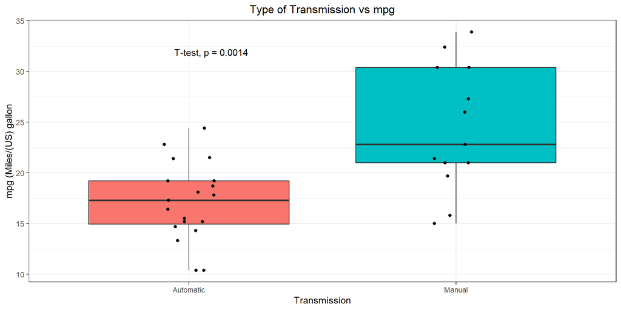

```r
library(ggpubr)
ggplot(mtcars2, aes(x=am, y=mpg, fill=am)) +
    geom_boxplot(outlier.shape=NA) +
    geom_jitter(height=0, width=0.1) +
    theme_bw() +
    theme(legend.position="none", plot.title = element_text(hjust = 0.5)) +
    labs(x="Transmission", y="mpg (Miles/(US) gallon", title="Type of Transmission vs mpg") +
    stat_compare_means(method="t.test", label.x=1, label.y.npc=0.9)
```

From the boxplots and subsequent t-test (p=0.0014), we have sufficient evidence to conclude that cars with manual transmissions provide better gas mileage than automatic transmission.

# Regression Models

In this section, we will attempt to use regression models to quantify the MPG difference between automatic and manual transmissions. To start, we can try a linear model to fit the variable `am` to the outcome `mpg`.

```r
fit1<-lm(mpg~am, mtcars)
summary(fit1)
```

```
##
## Call:
## lm(formula = mpg ~ am, data = mtcars)
##
## Residuals:
##     Min      1Q  Median      3Q     Max
## -9.3923 -3.0923 -0.2974  3.2439  9.5077
##
## Coefficients:
##             Estimate Std. Error t value Pr(>|t|)
## (Intercept)   17.147      1.125  15.247 1.13e-15 ***
## am             7.245      1.764   4.106 0.000285 ***
## ---
## Signif. codes:  0 '***' 0.001 '**' 0.01 '*' 0.05 '.' 0.1 ' ' 1
##
## Residual standard error: 4.902 on 30 degrees of freedom
## Multiple R-squared:  0.3598, Adjusted R-squared:  0.3385
## F-statistic: 16.86 on 1 and 30 DF,  p-value: 0.000285
```

Here, we see that the mean MPG for automatic cars is 17.1, while manual transmission provides 7.25 mpg more. However, the $R^2$ value suggests that transmission only accounts for 33.8% of the total variance, and thus a multivariate model might be a better fit to the data. Nonetheless, the p-value of < 0.05 for `am` suggests that there is a linear correlation with `mpg`.

Lets check the correlation of the other variables to mpg.

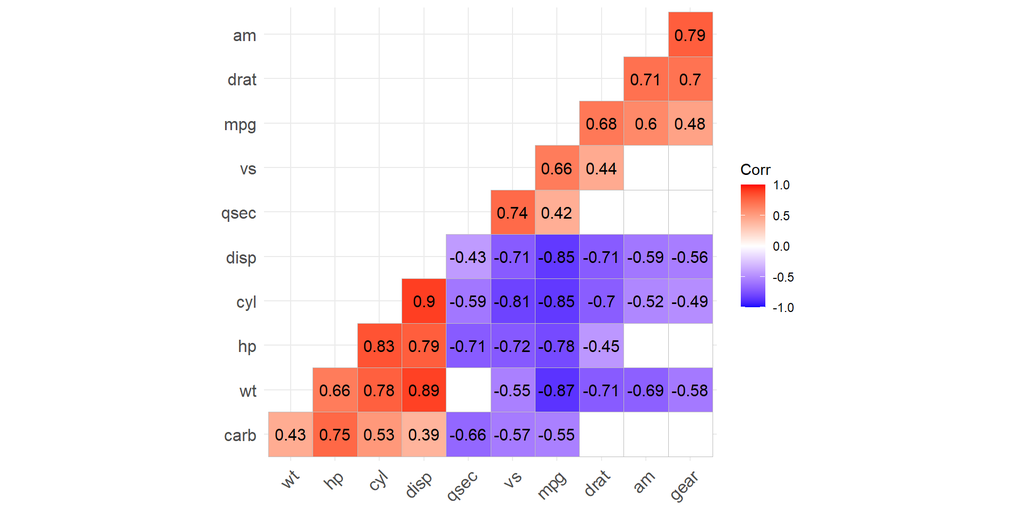

```r
library(ggcorrplot)
corr<-cor(mtcars)
p.mat<-cor_pmat(mtcars)
ggcorrplot(corr, hc.order = TRUE, type = "lower", lab = TRUE, p.mat=p.mat, insig="blank")
```

From the correlation data, we observe that the variables drat and vs has moderately strong positive correlations with mpg (~0.6), while disp, cyl, hp and wt has strong negative correlations with mpg (~-0.8). Furthermore, we also note that all the abovementioned variables are significantly correlated with mpg. We shall move forward with multivariate models and begin by doing a nested model testing.

```r
fit<-lm(mpg~., data=mtcars)
fit2<-update(fit, mpg~am+drat)
fit3<-update(fit, mpg~am+drat+vs)
fit4<-update(fit, mpg~am+disp)
fit5<-update(fit, mpg~am+disp+cyl)
fit6<-update(fit, mpg~am+disp+cyl+hp)
fit7<-update(fit, mpg~am+disp+cyl+hp+wt)
fit8<-update(fit, mpg~am+drat+vs+disp+cyl+hp+wt)
fit9<-update(fit, mpg~am+cyl)
fit10<-update(fit, mpg~am+cyl+hp)
fit11<-update(fit, mpg~am+cyl+hp+wt)
fit12<-update(fit, mpg~am+hp)
fit13<-update(fit, mpg~am+hp+wt)
fit14<-update(fit, mpg~am+wt)
anova(fit, fit1, fit2, fit3, fit4, fit5, fit6, fit7, fit8, fit9, fit10, fit11, fit12, fit13, fit14)
```

```
## Analysis of Variance Table
##
## Model  1: mpg ~ cyl + disp + hp + drat + wt + qsec + vs + am + gear + carb
## Model  2: mpg ~ am
## Model  3: mpg ~ am + drat
## Model  4: mpg ~ am + drat + vs
## Model  5: mpg ~ am + disp
## Model  6: mpg ~ am + disp + cyl
## Model  7: mpg ~ am + disp + cyl + hp
## Model  8: mpg ~ am + disp + cyl + hp + wt
## Model  9: mpg ~ am + drat + vs + disp + cyl + hp + wt
## Model 10: mpg ~ am + cyl
## Model 11: mpg ~ am + cyl + hp
## Model 12: mpg ~ am + cyl + hp + wt
## Model 13: mpg ~ am + hp
## Model 14: mpg ~ am + hp + wt
## Model 15: mpg ~ am + wt
##    Res.Df    RSS Df Sum of Sq       F    Pr(>F)
## 1      21 147.49
## 2      30 720.90 -9   -573.40  9.0711 1.779e-05 ***
## 3      29 573.64  1    147.26 20.9661 0.0001629 ***
## 4      28 339.99  1    233.65 33.2668 1.003e-05 ***
## 5      29 300.28 -1     39.71
## 6      28 252.08  1     48.20  6.8627 0.0160104 *
## 7      27 216.37  1     35.71  5.0849 0.0349350 *
## 8      26 163.12  1     53.25  7.5813 0.0119079 *
## 9      24 158.65  2      4.47  0.3179 0.7311188
## 10     29 271.36 -5   -112.71  3.2094 0.0262495 *
## 11     28 220.55  1     50.81  7.2341 0.0137216 *
## 12     27 170.00  1     50.56  7.1980 0.0139274 *
## 13     29 245.44 -2    -75.44  5.3706 0.0130693 *
## 14     28 180.29  1     65.15  9.2757 0.0061455 **
## 15     29 278.32 -1    -98.03 13.9571 0.0012194 **
## ---
## Signif. codes:  0 '***' 0.001 '**' 0.01 '*' 0.05 '.' 0.1 ' ' 1
```

From the nested model fit, we observe that the model with Df=1, lowest RSS, and significant p-value is model 8 with mpg ~ am + disp + cyl + hp + wt.

```r
summary(fit7)
```

```
##
## Call:
## lm(formula = mpg ~ am + disp + cyl + hp + wt, data = mtcars)
##
## Residuals:
##     Min      1Q  Median      3Q     Max
## -3.5952 -1.5864 -0.7157  1.2821  5.5725
##
## Coefficients:
##             Estimate Std. Error t value Pr(>|t|)
## (Intercept) 38.20280    3.66910  10.412 9.08e-11 ***
## am           1.55649    1.44054   1.080  0.28984
## disp         0.01226    0.01171   1.047  0.30472
## cyl         -1.10638    0.67636  -1.636  0.11393
## hp          -0.02796    0.01392  -2.008  0.05510 .
## wt          -3.30262    1.13364  -2.913  0.00726 **
## ---
## Signif. codes:  0 '***' 0.001 '**' 0.01 '*' 0.05 '.' 0.1 ' ' 1
##
## Residual standard error: 2.505 on 26 degrees of freedom
## Multiple R-squared:  0.8551, Adjusted R-squared:  0.8273
## F-statistic:  30.7 on 5 and 26 DF,  p-value: 4.029e-10
```

From the summary, we see that the model explains 82.7% of the variation as given by the $R^2$ value, and manual transmissions result in a 1.55 mpg increase over automatic transmissions.

# Appendix - Residual plots

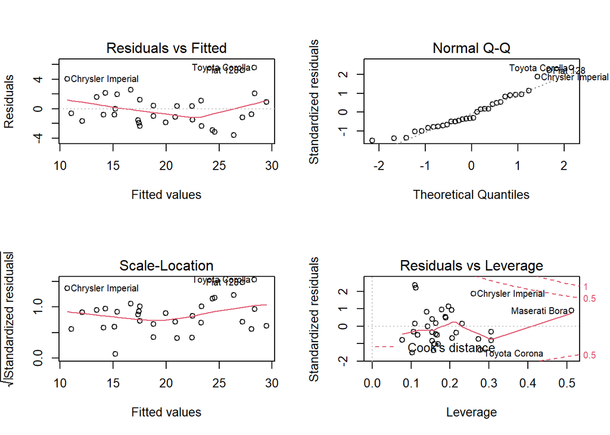

```r
par(mfrow = c(2,2))
plot(fit7)
```